# TRANSFORMADA CONTINUA DE FOURIER

## SISTEMAS Y SEÑALES

### Ingenieria de Telecomunicaciones

### Universidad Pontificia Bolivariana

### Por: Jose R. Zapata - https://joserzapata.github.io/

**joser.zapata@upb.edu.co**

```python
# Script para ver y ocultar el codigo del jupyter
from IPython.display import HTML

HTML('''<script>
  function code_toggle() {
    if (code_shown){
      $('div.input').hide('500');
      $('#toggleButton').val('Ver el Codigo de Python')
    } else {
      $('div.input').show('500');
      $('#toggleButton').val('Ocultar el Codigo')
    }
    code_shown = !code_shown
  }

  $( document ).ready(function(){
    code_shown=false;
    $('div.input').hide()
  });
</script>
<form action="javascript:code_toggle()">
<input type="submit" id="toggleButton" value="Ver el Codigo de Python"></form>''')
```

# Transformada de Fourier

La transformada de Fourier, denominada así por Joseph Fourier, es una transformación matemática empleada para transformar señales entre el dominio del tiempo (o espacial) y el dominio de la frecuencia, que tiene muchas aplicaciones en la física y la ingeniería.

La transformada de Fourier es la generalizacion de la serie de Fourier para señales no periodicas, osea señales de energia finita, la representacion en frecuencia (Espectro de frecuencia) sera continuo osea que las exponenciales complejas estaran infinitesimalmente cercanas en frecuencia.

Para obtener la Transformada de Fourier a partir de las series de Fourier, se define que una señal aperiodica es una señal periodica pero con periodo tendiendo a infinito $(T \rightarrow \infty)$

En las series de Fourier se puede ver que si se aumenta el periodo $(T)$ las componentes se hacen mas cercanas en frecuencia, basandonos en la relacion del periodo y la frecuencia angular $\large \omega = \frac{2 \pi}{T}$, si se aumenta $T$ la frecuencia se vuleve mas pequeña, entonces las componentes de frecuencia se hacen mas cercanas.

# Demostracion de la Tranformada de Fourier para señales Aperiodicas

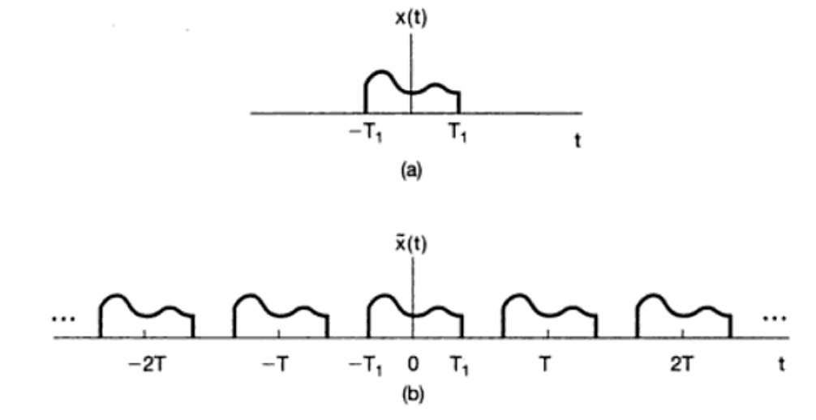

$$ \large \widetilde{x}(t)= \sum_{k = - \infty}^{+ \infty}a_k e^{j k \omega_0 t} \\ \large a_k = \frac{1}{T}\int_{-T_1}^{T_1} \widetilde{x}(t)e^{-j k \omega_0 t} \mathbb{d}t $$$$ \large x(t) = \widetilde{x}(t) \qquad \forall \: t \in [-T_1,T_1] \rightarrow \\ \large a_k = \frac{1}{T}\int_{-T_1}^{T_1} x(t)e^{-j k \omega_0 t} \mathbb{d}t = \frac{1}{T}\int_{-\infty}^{\infty} x(t)e^{-j k \omega_0 t} \mathbb{d}t $$

Definiendo la envolvente $\large X(j\omega) = T a_k$ entonces

$$ \large X(j\omega) = \int_{-\infty}^{\infty} x(t)e^{-j \omega t} \mathbb{d}t \\ \quad\\ a_k = \frac{X(jk\omega_0)}{T} $$

combinando

$$ \large \widetilde{x}(t)= \sum_{k = - \infty}^{+ \infty} \frac{X(jk\omega_0)}{T} e^{j k \omega_0 t} \qquad \omega_0 = \frac{2 \pi}{T} \\ \large \widetilde{x}(t)= \frac{1}{2 \pi}\sum_{k = - \infty}^{+ \infty}X(jk\omega_0) e^{j k \omega_0 t}\omega_0 $$

Si $\large \: T \rightarrow \infty \:$ entonces $\large \: \widetilde{x}(t) \Rightarrow x(t) \:$ entonces $\large \omega_0 \Rightarrow 0$

Por lo tanto $\large \widetilde{x}(t)$ converge en una integral obteniendo la Transformada Inversa de Fourier, $x(t) = \mathcal{F}^{-1} \{ X(j \omega) \}$:

$$ \large \boxed{x(t) = \frac{1}{2 \pi} \int_{-\infty}^{\infty} X(j \omega) \, e^{j \omega t} \; \mathbb{d}\omega} \\ $$

Transformada de Fourier $X(j \omega) = \mathcal{F} \{ x(t) \}$ $$ \large \boxed{X(j \omega) = \int_{-\infty}^{+ \infty} x(t) \, e^{-j \omega t} \; \mathbb{d}t} $$

Donde $\large X(j \omega)$ es el Espectro de Frecuencia de $\large x(t)$

# Tranformadas de Fourier de Señales Especiales

```python
# Importar librerias basicas
import numpy as np
import matplotlib.pyplot as plt
import sympy as sym

%matplotlib inline
plt.style.use('bmh') # estilo de las graficas
from IPython.display import Latex # para visualizar ecuaciones en jupyter
```

```python
sym.init_printing()

t, w = sym.symbols('t omega', real=True)

def fourier_transform(x):
    return sym.transforms._fourier_transform(x, t, w, 1, -1, 'Fourier')
```

## T. Fourier Impulso de Dirac

La transformación $\mathcal{F} \{ \delta(t) \}$ del impulso de Dirac se deriva al introducir $\delta(t)$ en La definición de la transformada de Fourier y la explotación de la propiedad de integracion de la función delta de Dirac.

$$ \mathcal{F} \{ \delta(t) \} = \int_{-\infty}^{\infty} \delta(t) \, e^{-j \omega t} dt = 1 $$

Utilizando el Modulo `sympy` se puede evaluar la integral o calcular la transformada de fourier de delta

```
t, w = sym.symbols('t omega', real=True)

X = sym.integrate(sym.DiracDelta(t)*sym.exp(-sym.I*w*t), (t, -sym.oo, sym.oo))
```

```python
t, w = sym.symbols('t omega', real=True)

X = sym.integrate(sym.DiracDelta(t)*sym.exp(-sym.I*w*t), (t, -sym.oo, sym.oo))
X
```

$\displaystyle 1$

```
X = fourier_transform(sym.DiracDelta(t))
```

```python
X = fourier_transform(sym.DiracDelta(t))
X
```

$\displaystyle 1$

Lo que me indica que el espectro de frecuencia de un impulso de Dirac esta en todas las frecuencias con un valor de 1.

## T. Fourier Exponencial decreciente

$\large x(t) = e^{-at} \mu (t)$

para $a = 1$

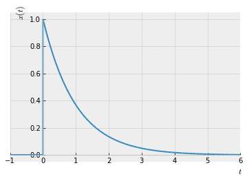

```python
a = sym.exp(-t)*sym.Heaviside(t)
sym.plot(a, (t, -1, 6), xlabel=r'$t$', ylabel=r'$x(t)$');
```

```python
XW = fourier_transform(sym.exp(-t)*sym.Heaviside(t))
XW
```

$\displaystyle \frac{1}{i \omega + 1}$

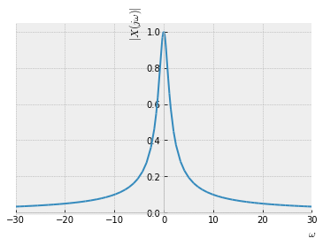

```python
sym.plot(sym.Abs(XW), (w, -30, 30), xlabel=r'$\omega$', ylabel=r'$|X(j\omega)|$');
```

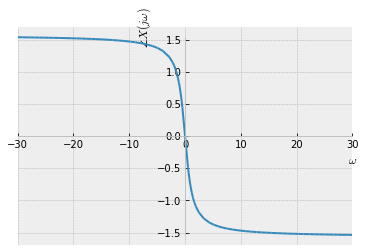

```python
sym.plot(sym.arg(XW), (w, -30, 30), xlabel=r'$\omega$', ylabel=r'$\angle X(j\omega)$');
```

## T. Fourier de un Pulso Rectangular

La transformación de Fourier $ \mathcal{F} \{\text{rect}(t) \}$ de la señal rectangular se obtiene mediante la evaluación explícita de la definición. \begin{equation} \mathcal{F} \{ \text{rect}(t) \} = \int_{-\infty}^{\infty} \text{rect}(t) \, e^{-j \omega t} \; dt = \int_{- \frac{1}{2}}^{\frac{1}{2}} e^{-j \omega t} \; dt = \frac{\sin(\frac{\omega}{2})}{\frac{\omega}{2}} \end{equation}

El resultado se abrevia comúnmente en términos de [función sinc](https://en.wikipedia.org/wiki/Sinc_function)

\begin{equation} \text{sinc}(x) = \begin{cases} \frac{sin(x)}{x} & \text{for } x \neq 0 \\ 1 & \text{for } x = 0 \end{cases} \end{equation}

Tenga en cuenta que el valor en $ x = 0 $ se ha obtenido aplicando [la regla de L'Hôpital](https://es.wikipedia.org/wiki/Regla_de_l%27H%C3%B4pital) a $ \frac{ sin(x)}{x} $. La función sinc es una función importante en el procesamiento de señales (digitales) y la ingeniería de comunicaciones. Muestra las siguientes propiedades 1. Su valor máximo es uno en $ x = 0 $ 2. Su amplitud decae con $ \frac{1}{| x |} $ 3. Sus ceros se encuentran en $ x_0 = n \cdot \pi $ para $ n \in \mathcal{Z} \setminus \{0 \} $

1. $\int_{-\infty}^{\infty} \text{sinc}(t) \; dt = \pi$

```python
class rect(sym.Function):

    @classmethod
    def eval(cls, arg):
        return sym.Heaviside(arg + sym.S.Half) - sym.Heaviside(arg - sym.S.Half)
```

```
Ancho del pulso desde cero = 0.5
```

$x(t) = \mu (t+0.5) - \mu (t-0.5)$

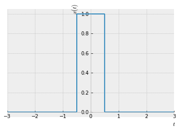

```python
print("Ancho del pulso desde cero = 0.5")
display(Latex('$x(t) = \mu (t+0.5) - \mu (t-0.5)$'))
sym.plot(rect(t), (t, -3, 3), xlabel=r'$t$', ylabel=r'$x(t)$');
```

```python
print('La transformada de Fourier de x(t) sera:')
XW = fourier_transform(rect(t))
XW
```

```
La transformada de Fourier de x(t) sera:
```

$\displaystyle \frac{2 \sin{\left(\frac{\omega}{2} \right)}}{\omega}$

Como la trasnformada de Fourier es solo Real entonces no es necesario graficar la Magnitud y la Fase por separado

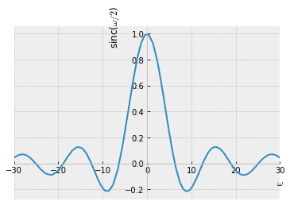

```python
sym.plot(XW, (w, -30, 30), xlabel=r'$\omega$', ylabel=r'sinc($\omega / 2$)');
```

El espectro de frecuencia de La señal pulso rectangular es va desde $-\infty$ Hasta $+\infty$ lo que indica que presenta fenomeno de Gibbs

De forma General la transformada de Fourier de un Pulso Rectangular en el tiempo que este centrada en cero y el valor del ancho desde cero sea $T_1$ sera: $$ X(j \omega) = \frac{2 \sin(\omega T_1)}{\omega}$$

## T. Inversa de Fourier de una señal Sinc(x)

```python
def inverse_fourier_transform(X):
    return sym.transforms._fourier_transform(X, w, t, 1/(2*sym.pi), 1, 'Inverse Fourier')
```

$X(j \omega) = \frac{2 \sin (\frac{\omega}{2})}{\omega}$

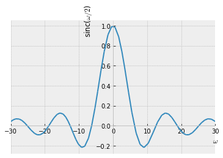

```python
t, w = sym.symbols('t omega')
display(Latex(r'$X(j \omega) = \frac{2 \sin (\frac{\omega}{2})}{\omega}$'))
XW = sym.sinc(w/2)
sym.plot(XW, (w, -30, 30), xlabel=r'$\omega$', ylabel=r'sinc($\omega / 2$)');
```

```python
x = inverse_fourier_transform(XW)
x
```

$\displaystyle \begin{cases} 1 & \text{for}\: \frac{\left|{\frac{1}{t^{2}}}\right|}{4} > 1 \\0 & \text{otherwise} \end{cases}$

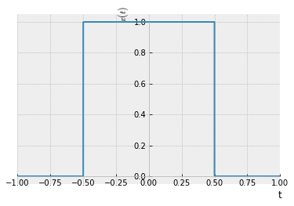

```python
sym.plot(x, (t,-1,1), ylabel=r'$x(t)$');
```

# Convergencia

Para que exista la transformada de fourier se debe cumplir que:

1. $\large x(t)$ sea absolutamente integrable $$ \large \int_{-\infty}^{\infty} | x(t) | \; dt < \infty $$
2. $\large x(t)$ debe tener un numero finito de intervalos en cualquier intervalo finito de la señal
3. $\large x(t)$ debe tener un numero finito de discontinuidades en cualquier intervalo finito de la señal

# Transformada de Fourier para Señales Periodicas

Para obtener la transformada de Fourier para una señal periodica y obtener un resultado general se supone $\large X(j \omega) = \mathcal{F} \{ x(t) \}$, donde $\large X(j \omega)$ es la representacion en frecuencia de $\large x(t)$.

Supongamos que el espectro de $\large x(t)$ consiste en un solo impulso de area = $\large \large 2 \pi$ en $\large \omega = \omega_0$ $$ \large X(j \omega) = 2 \pi \delta(\omega - \omega_0) \qquad \rightarrow \\ \large x(t) = \frac{1}{2 \pi}\int_{- \infty}^{ \infty} ( 2 \pi \delta(\omega - \omega_0))e^{j \omega t} \mathbb{d}\omega \\ \large x(t) = e^{j \omega_0 t} $$ De forma general si suponemos: $$ \large X(j \omega) = \sum_{k= -\infty}^{\infty} 2 \pi \: a_k \:\delta(\omega - \omega_0) \quad \rightarrow \\ \large x(t) = \frac{1}{2 \pi}\int_{- \infty}^{ \infty} ( \sum_{k= -\infty}^{\infty} 2 \pi \: a_k \: \delta(\omega - \omega_0))e^{j \omega t} \mathbb{d}\omega \\ \large x(t) = \sum_{k= -\infty}^{\infty}a_k e^{j k \omega_0 t} \: \equiv \: \text{Serie de Fourier} $$

La Transformada de Fourier de una señal periodica con coeficiente de series de Fourier $= a_k$ se puede entender como un tren de impulsos que ocurren a las frecuencias relacionadas armonicamente y para las cuales el area del impulso es la K-esima frecuencia armonica $K \omega_0$ es $2 \pi$ veces el K- esimo coeficiente de la serie de Fourier $a_k$.

Entonces en Resumen la transformada de Fourier de una señal periodica es calcular las series de Fourier y multiplicar cada coeficiente por $2 \pi$.

**Ejemplo**

```
Periodo = 5
Ancho del pulso = 2
```

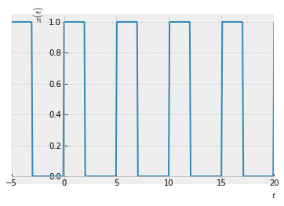

```python
mu = sym.symbols('mu', integer=True)
t = sym.symbols('t', real=True)
T = 2
Tp = 5

def pulse_train(T, Tp):
    n = sym.symbols('n', integer=True)
    x0 = sym.Piecewise((0, t < 0), (1, t < T), (0, True))
    return sym.summation(x0.subs(t, t+n*Tp), (n, -10, 10))

print(f"Periodo = {Tp}")
print(f"Ancho del pulso = {T}")
import warnings
warnings.filterwarnings("ignore", module="sympy.plot")
sym.plot(pulse_train(T, Tp), (t, -5, 20), xlabel='$t$', ylabel='$x(t)$', adaptive=False);
```

```python
X_mu = sym.exp(-sym.I * mu * sym.pi * T/Tp) * T * sym.sinc(mu * sym.pi * T/Tp)
X_mu
```

$\displaystyle 2 e^{- \frac{2 i \pi \mu}{5}} \operatorname{sinc}{\left(\frac{2 \pi \mu}{5} \right)}$

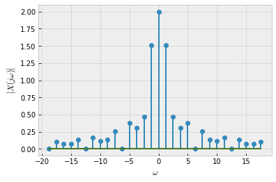

```python
Xn = sym.lambdify(mu, sym.Abs(X_mu), 'numpy')

n = np.arange(-15, 15)
plt.stem(n*2*np.pi/Tp, Xn(n))
plt.xlabel('$\omega$')
plt.ylabel('$|X(j \omega)|$');
```

Preguntas:

- Cambie la relación T / Tp del codigo. ¿Cómo cambia el espectro del tren de pulsos?
- ¿Puedes deducir la periodicidad(Tp) de la señal observando su espectro?
- Calcule la potencia promedio del tren de pulsos en el dominio de la frecuencia aplicando el teorema de Parseval.

## Ejercicios

- Transformada de Fourier de $x(t) = \sin(\omega_0 t)$
- Transformada de Fourier de $x(t) = \cos(\omega_0 t)$
- Si $x(t) = \sum_{k = -\infty}^{\infty} \delta (t - KT)$

# Propiedades de la Tranformada de Fourier

## Linealidad

$$ \large x(t) \overset{f}{\longleftrightarrow} X(j\omega) \\ \large y(t) \overset{f}{\longleftrightarrow} Y(j\omega) \\ \large ax(t) + by(t) \overset{f}{\longleftrightarrow} a X(j\omega) + b Y(j\omega) $$

## Desplazamiento en el Tiempo

$$ \large \boxed{x(t-t_o)\overset{f}{\longleftrightarrow}e^{-j\omega t_0} X(j\omega) } $$

Cambia la fase pero no la magnitud

## Conjugacion y Simetria Conjugada

$$ \large \boxed{x^*(t) \overset{f}{\longleftrightarrow} X^*(-j \omega)} $$

Si $x(t) \in \mathbb{R}e \:$ entonces $\: X(-j \omega) = X^*(j \omega)$

## Diferenciacion e Integracion

$$ \large \boxed{\frac{\mathbb{d}x(t)}{\mathbb{d}t} \overset{f}{\longleftrightarrow} j \omega X(j \omega)} $$$$ \large \boxed{\int_{- \infty}^{t}x(\tau)\mathbb{d}\tau \overset{fs}{\longleftrightarrow} \left ( \frac{1}{j \omega} \right) X(j \omega) + \pi X(0)\delta(\omega)} $$

### Ejemplo:

- La función delta de dirac $\delta(t)$ es igual a la primera deriva de la función paso $\mu(t)$, o en caso contrario la función paso es igual a la integral del delta de dirac, entonces si conozco la transformada de Fourier de la señal delta de dirac puedo hallar la transformada de Fourier de la señal paso.

$$ \mathcal{F} \{ \delta(t) \} = 1 \\ \frac{d \mu(t)}{dt} = \delta(t) \: \rightarrow \\ \mathcal{F} \{ \mu(t) \} = \frac{1}{j \omega} + \pi \cdot \delta(\omega) $$

- La funcion rampa $r(t)$ se puede expresar como la integral de la funcion paso $\mu (t)$

$$ r(t) = \int_{-\infty}^{t} \mu(\tau) \; d\tau $$

Aplicando el teorema de la integracion podemos obtener la transformada de Fourier de la funcion Paso

## Escalamiento de Tiempo y Frecuencia

$$ \large \boxed{x(\alpha t) \overset{f}{\longleftrightarrow} \frac{1}{|\alpha|} X \left( \frac{j \omega}{\alpha} \right )} $$$$ \large x(- t) \overset{f}{\longleftrightarrow} X(-j \omega) $$

### Ejemplo

```python
t, w = sym.symbols('t omega')
a = sym.symbols('a', positive=True)

x = sym.Heaviside(t + sym.S.Half/a) - sym.Heaviside(t - sym.S.Half/a)
X = fourier_transform(x)
print(f'X(jw) =')
X
```

```
X(jw) =
```

$\displaystyle \frac{2 \sin{\left(\frac{\omega}{2 a} \right)}}{\omega}$

```
a = 0.5
```

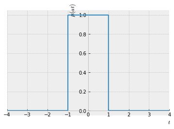

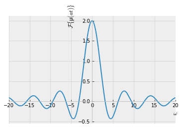

```python
values = {a: 1/2}
print(f'a = 0.5')
sym.plot(x.subs(values), (t, -4,4), xlabel=r'$t$', ylabel=r'$\mathrm{\mu}(a t)$');
sym.plot(X.subs(values), (w, -20, 20), xlabel=r'$\omega$', ylabel=r'$\mathcal{F} \{ \mathrm{μ}(a t) \}$');
```

```
a = 2
```

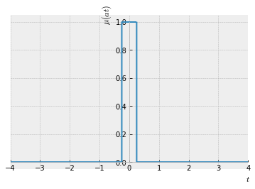

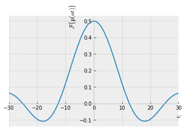

```python
values = {a: 2}
print(f'a = 2')
sym.plot(x.subs(values), (t, -4, 4), xlabel=r'$t$', ylabel=r'$\mathrm{\mu}(a t)$');
sym.plot(X.subs(values), (w, -30, 30), xlabel=r'$\omega$', ylabel=r'$\mathcal{F} \{ \mathrm{μ}(a t) \}$');
```

## Dualidad

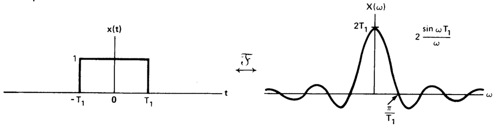

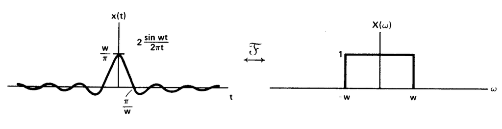

Se puede comprobar si tenemos un pulso en la frecuencia y calculamos la transformada inversa de Fourier, y lo comparamos con el ejercicio desarrollado anteriormente sobre la transformada de Fourier de un pulso en el tiempo.

```
Ancho del pulso desde cero = 0.5 rads/seg
```

$X(j \omega) = \mu (\omega +0.5) - \mu ( \omega -0.5)$

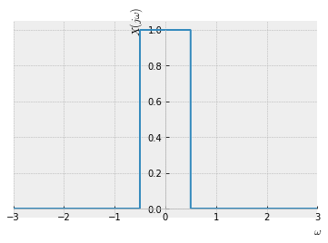

```python
print("Ancho del pulso desde cero = 0.5 rads/seg")
display(Latex('$X(j \omega) = \mu (\omega +0.5) - \mu ( \omega -0.5)$'))
XW = rect(w)
sym.plot(XW, (w, -3, 3), xlabel=r'$\omega$', ylabel=r'$X(j \omega) $');
```

```python
x = inverse_fourier_transform(XW)
x
```

$\displaystyle \frac{\sin{\left(\frac{t}{2} \right)}}{\pi t}$

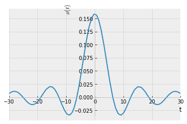

```python
sym.plot(x, (t,-30,30), ylabel=r'$x(t)$');
```

En general, para cualquier par de transformadas, hay un par dual con las variables de tiempo y frecuencia intercambiadas.

### Derivacion en la Frecuencia

$$ \large -j t x(t) \overset{f}{\longleftrightarrow} \frac{d X(j \omega)}{d \omega} $$

### Integracion en la Frecuencia

$$ \large \frac{1}{jt}x(t) + \pi x(0) \delta(t) \overset{f}{\longleftrightarrow} \int_{\infty}^{\omega}x(\eta)\delta(\eta) $$

### Desplazamiento en la Frecuencia

Es el concepto que se utiliza en Modulacion, ver la propiedad mas adelante $$ \large e^{j \omega_0 t}\cdot x(t) \overset{f}{\longleftrightarrow} X\left(j (\omega - \omega_0) \right) $$

## Relacion de Parseval

$$ \large \boxed{\int_{-\infty}^{\infty} | x(t) |^2 \; dt = \frac{1}{2 \pi} \int_{-\infty}^{\infty} | X(j \omega) |^2 \; d\omega} $$

### Ejemplo

La energía de la señal pulso rectangular $\text{rect}(t)$ se calcula en el tiempo y el dominio espectral mediante la evaluación de las integrales respectivas. Primero se evalúa el dominio del tiempo

$$ E_t = \int_{-\infty}^{\infty} | \text{rect}(t) |^2 \; dt = \int_{- \frac{1}{2}}^{\frac{1}{2}} 1 \; dt $$

Codigo en python para evaluar la integral:

```
E_t = sym.integrate(1, (t, -sym.S.Half, sym.S.Half))
```

```python
E_t = sym.integrate(1, (t, -sym.S.Half, sym.S.Half))
print('Energia en el Tiempo E_t = {E_t}')
```

[output not shown]

La energía en el dominio espectral se calcula evaluando

$$ E_f = \frac{1}{2 \pi} \int_{-\infty}^{\infty} \left| \text{sinc}\left(\frac{\omega}{2}\right) \right|^2 \; d\omega $$

Codigo en python para evaluar la integral:

```
E_f = 1/(2*sym.pi) * sym.integrate(sym.sinc(w/2)**2, (w, -sym.oo, sym.oo))
```

```python
E_f = 1/(2*sym.pi) * sym.integrate(sym.sinc(w/2)**2, (w, -sym.oo, sym.oo))
print('Energia en la frecuencia  E_f = {E_f}')
```

[output not shown]

## Convolucion

$$ \large \boxed{y(t) = x(t) * h(t) \overset{f}{\longleftrightarrow} Y(j \omega)= X(j \omega) \cdot H(j \omega)} $$

$$ \begin{align} \large \mathcal{F} \{ x(t) * h(t) \} &= \int_{-\infty}^{\infty} \left( \int_{-\infty}^{\infty} x(\tau) \cdot h(t-\tau) \; d \tau \right) e^{-j \omega t} \; dt \\ \large &= \int_{-\infty}^{\infty} \left( \int_{-\infty}^{\infty} h(t-\tau) \, e^{-j \omega t} \; dt \right) x(\tau) \; d\tau \\ \large &= H(j \omega) \cdot \int_{-\infty}^{\infty} x(\tau) \, e^{-j \omega \tau} \; d \tau \\ \large &= H(j \omega) \cdot X(j \omega) \end{align} $$

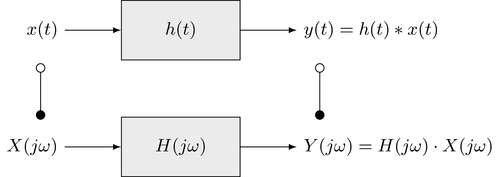

## Multiplicacion

$$ \large \boxed{x(t) \cdot h(t) \overset{f}{\longleftrightarrow} \frac{1}{2 \pi} \left[ X(j \omega) * H(j \omega) \right]} $$

El teorema de multiplicación se puede probar de manera similar al teorema de convolución calculando la transformada inversa de Fourier de los espectros convolucionados

$$ \begin{split} \mathcal{F}^{-1} \left\{ \frac{1}{2 \pi} X(j \omega) * Y(j \omega) \right\} &= \frac{1}{2 \pi} \int_{-\infty}^{\infty} \left( \frac{1}{2 \pi} \int_{-\infty}^{\infty} X(j \nu) \cdot Y(j (\omega-\nu)) \; d \nu \right) e^{j \omega t} \; d\omega \\ &= \frac{1}{2 \pi} \int_{-\infty}^{\infty} \left( \frac{1}{2 \pi} \int_{-\infty}^{\infty} Y(j (\omega-\nu)) \, e^{j \omega t} \; d\omega \right) X(j \nu) \; d\nu \\ &= y(t) \cdot \frac{1}{2 \pi} \int_{-\infty}^{\infty} X(j \nu) \, e^{j \nu t} \; d \nu \\ &= y(t) \cdot x(t) \end{split} $$

Alternativamente, la dualidad de la transformada de Fourier se puede aplicar al teorema de convolución. Las aplicaciones del teorema de multiplicación incluyen la modulación y cuando se aplica una ventana a una señal. El primero conduce al teorema de modulación introducido más tarde, el segundo se puede ilustrar con el siguiente ejemplo.

```python
def convolve(x, y, var):
    tau = sym.symbols('tau')
    return sym.integrate(x.subs(var, tau) * y.subs(var, var - tau), (tau, -sym.oo, sym.oo))
```

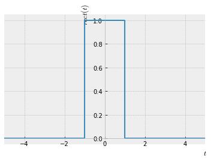

$x(t) = cos(\omega _0 t)$

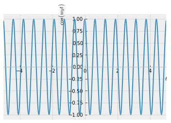

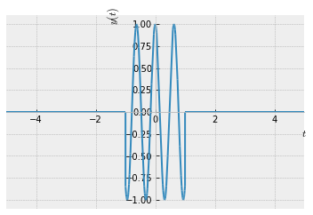

```python
t, w = sym.symbols('t omega')
w0, a = sym.symbols('omega0 a')

class rect(sym.Function):

    @classmethod
    def eval(cls, arg):
        return sym.Heaviside(arg + sym.S.Half) - sym.Heaviside(arg - sym.S.Half)


values = {w0: 10, a: 1/2}

y1 = rect(a*t)
y2 = sym.cos(w0*t)

display(Latex('$w(t) = rect(t)$'))
sym.plot(y1.subs(values), (t, -5, 5), xlabel=r'$t$', ylabel=r'$rect(t)$');
display(Latex('$x(t) = cos(\omega _0 t)$'))
sym.plot(y2.subs(values), (t, -5, 5), xlabel=r'$t$', ylabel=r'$cos(w_0t)$');

display(Latex('$x(t) = rect(t) \cdot cos(\omega _0 t)$'))
y = rect(a*t) * sym.cos(w0*t)

sym.plot(y.subs(values), (t, -5, 5), xlabel=r'$t$', ylabel=r'$y(t)$');
```

```python
W = 1/abs(a) * sym.sinc(w/(2*a))
X = sym.pi*(sym.DiracDelta(w + w0) + sym.DiracDelta(w - w0))

Y = 1/(2*sym.pi) * convolve(W, X, w)
Y
```

$\displaystyle \frac{\operatorname{sinc}{\left(\frac{\omega - \omega_{0}}{2 a} \right)} + \operatorname{sinc}{\left(\frac{\omega + \omega_{0}}{2 a} \right)}}{2 \left|{a}\right|}$

$W(j \omega)$

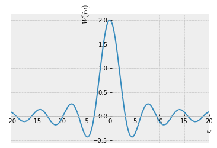

$Y(j \omega) = X(j \omega) * W(j \omega)$

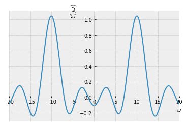

```python
values = {w0: 10, a: 1/2}

display(Latex('$W(j \omega)$'))
sym.plot(W.subs(values), (w, -20, 20), xlabel=r'$\omega$', ylabel=r'$W(j \omega)$');

display(Latex('$X(j \omega) = \delta(\omega + \omega_0) + \delta(\omega - \omega_0)$'))

display(Latex('$Y(j \omega) = X(j \omega) * W(j \omega)$'))
sym.plot(Y.subs(values), (w, -20, 20), xlabel=r'$\omega$', ylabel=r'$Y(j \omega)$');
```

## Modulacion con Sinusoidal

$$ \large e^{j \omega_0 t}\cdot x(t) \overset{f}{\longleftrightarrow} X\left(j (\omega - \omega_0) \right) $$

# Sistemas Caracterizados por Ecuaciones Diferenciales con Coeficientes Constantes

En los sistemas LTI la relación de entrada salida se puede expresar mediante una ecuación diferencial lineal de coeficientes constantes. $$ \large \sum_{n=0}^{N} \alpha_n \frac{d^n \:y(t)}{d t^n} = \sum_{m=0}^{M} \beta_m \frac{d^m \: x(t)}{d t^m} $$ Conociento la ecuacion Matematica qeu modela el sistema se puede obtener la respuesta del sistema ante cualquier entrada, ya que se puede obtener la respuesta al impulso.

$$ \large \mathcal{F} \left \{ \sum_{n=0}^{N} \alpha_n \frac{d^n \:y(t)}{d t^n} \right \} = \mathcal{F} \left \{ \sum_{m=0}^{M} \beta_m \frac{d^m \: x(t)}{d t^m}\right \} \\ \large \sum_{n=0}^{N} \alpha_n \mathcal{F} \left \{ \frac{d^n \:y(t)}{d t^n} \right \} = \sum_{m=0}^{M} \beta_m \mathcal{F} \left \{ \frac{d^m \: x(t)}{d t^m}\right \} \\ \large \sum_{n=0}^{N} \alpha_n (j \omega)^n \:Y(j \omega) = \sum_{m=0}^{M} \beta_m (j \omega)^m \: X(j \omega) \rightarrow \\ \large Y(j \omega)\sum_{n=0}^{N} \alpha_n (j \omega)^n = X(j \omega) \sum_{m=0}^{M} \beta_m (j \omega)^m \\ \large \frac{Y(j \omega)}{X(j \omega)} = \frac{\sum_{m=0}^{M} \beta_m (j \omega)^m }{\sum_{n=0}^{N} \alpha_n (j \omega)^n}\\ $$

Del Teorema de convolucion de Fourirer sabemos que $$ \large \mathcal{F} \{y(t) = x(t) * h(t) \} = X(j \omega) \cdot H(j \omega) \\ \large Y(j \omega) = H(j \omega)X(j \omega) \rightarrow H(j \omega) = \frac{Y(j \omega)}{X(j \omega)} $$ $$ \large \boxed{H(j \omega) = \frac{Y(j \omega)}{X(j \omega)} = \frac{\sum_{m=0}^{M} \beta_m (j \omega)^m }{\sum_{n=0}^{N} \alpha_n (j \omega)^n}} \equiv \text{Respuesta en Frecuencia del sistema} $$ $$ \large \mathcal{F}^{-1} \{H (j \omega)\} = h(t) \equiv \text{Respuesta al impulso} $$

## Ejemplo:

- La siguiente ecuacion diferencial de coeficientes constantes se obtiene de un sistema fisico $$ \frac{d\:y(t)}{d t} + ay(t) = x(t) \qquad a>0 $$ Calcular la Respuesta en frecuencia y la respuesta al impulso

## Ejercicio:

- Calcular la Respuesta en frecuencia y la respuesta al impulso del siguiente sistema reresentado por ecuaciones diferenciales de coeficientes constantes

$$ \large \frac{d^2\:y(t)}{d t^2} + 4 \frac{d\:y(t)}{d t} + 3 y(t) = \frac{d\:x(t)}{d t} + 2 x(t) $$

- Si $\large x(t) = e^{-t}$ calcular $\large y(t)$

# REFERENCIAS

- https://nbviewer.jupyter.org/github/spatialaudio/signals-and-systems-lecture/blob/master/fourier_transform/definition.ipynb
- https://nbviewer.jupyter.org/github/spatialaudio/signals-and-systems-lecture/blob/master/fourier_transform/theorems.ipynb
- https://nbviewer.jupyter.org/github/spatialaudio/signals-and-systems-lecture/blob/master/fourier_transform/table_theorems_transforms.ipynb

**Phd. Jose R. Zapata**

- https://joserzapata.github.io/
- https://twitter.com/joserzapata
- joser.zapata@upb.edu.co